# Tensile Strength Exploratory Analysis

Author

Lohit Marla

#### An engineer wants to see whether the cotton weight percentage in a synthetic fiber affects its tensile strength. The cotton weight percentage, *CWP* is fixed at five different levels, i.e., 15%,20, and 35%. Each percentage level is assigned five experimental units and the tensile strength of the fabric is measured on each of them. The randomization is specified in the column *Run Number*.

The goal of the engineer is to investigate whether tensile strength is the same across all levels of cotton weight percentage.

```r
library("ACSWR")
library("emmeans")
data("tensile")
str(tensile)
```

```
'data.frame':   25 obs. of  4 variables:
 $ Test_Sequence   : int  1 2 3 4 5 6 7 8 9 10 ...
 $ Run_Number      : int  8 18 10 23 17 5 14 6 15 20 ...
 $ CWP             : int  20 30 20 35 30 15 25 20 25 30 ...
 $ Tensile_Strength: int  12 19 17 7 25 7 14 12 18 22 ...
```

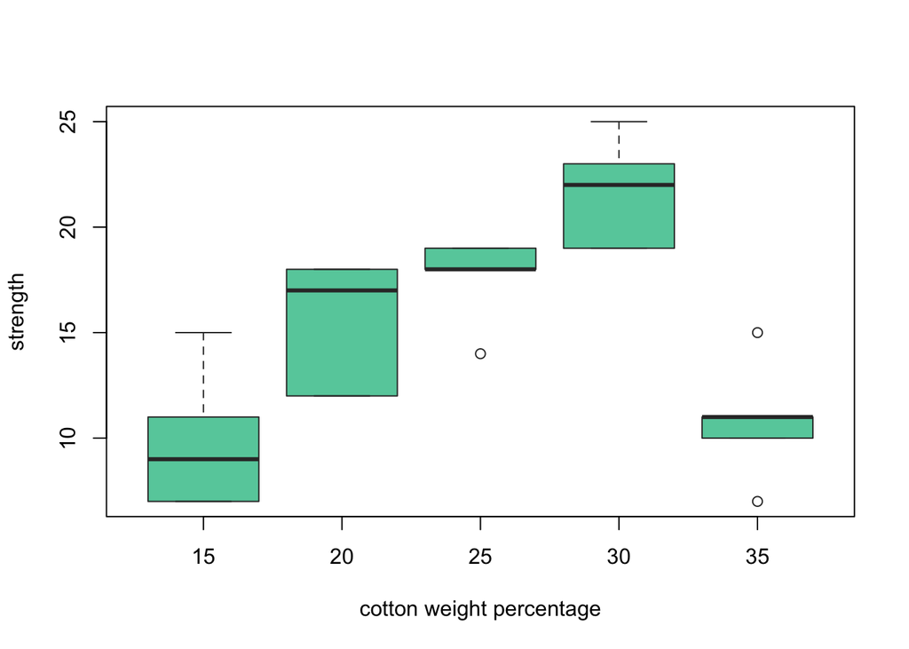

```r
boxplot(tensile$Tensile_Strength ~ tensile$CWP, xlab="cotton weight percentage",
        ylab="strength", border = "grey20", col="aquamarine3")
```

From the above chart we draw some information that the tensile strength was increased from the CWP 15% to 30% and got declined at the 35 CWP. At 15% of CWP values got extended till 15 for strength and the data looks normal whereas remaining all the other CWP from 20%-35% the data is skewed along with the outlier for 25% and 35%.

```r
#checking normality assumptions for Bartlett's Test

unique_levels <- unique(tensile$CWP)

# Perform Shapiro-Wilk test for normality for each CWP level
for(level in unique_levels) {
  subset_data <- tensile[tensile$CWP == level, ]
  shapiro_test <- shapiro.test(subset_data$Tensile_Strength)
  cat(paste("CWP Level:", level, " - p-value:", shapiro_test$p.value, "\n"))
}
```

```
CWP Level: 20  - p-value: 0.0322816051567101
CWP Level: 30  - p-value: 0.421149656082093
CWP Level: 35  - p-value: 0.679901851799461
CWP Level: 15  - p-value: 0.314039557109439
CWP Level: 25  - p-value: 0.0233242868158401
```

```r
bartlett_test_result <- bartlett.test(tensile$Tensile_Strength, tensile$CWP)
bartlett_test_result
```

```
    Bartlett test of homogeneity of variances

data:  tensile$Tensile_Strength and tensile$CWP
Bartlett's K-squared = 0.93309, df = 4, p-value = 0.9198
```

```r
tensile$CWP <- as.factor(tensile$CWP)
str(tensile)
```

```
'data.frame':   25 obs. of  4 variables:
 $ Test_Sequence   : int  1 2 3 4 5 6 7 8 9 10 ...
 $ Run_Number      : int  8 18 10 23 17 5 14 6 15 20 ...
 $ CWP             : Factor w/ 5 levels "15","20","25",..: 2 4 2 5 4 1 3 2 3 4 ...
 $ Tensile_Strength: int  12 19 17 7 25 7 14 12 18 22 ...
```

```r
aovmod <- aov(Tensile_Strength ~ factor(CWP), data = tensile)
summary(aovmod)
```

```
            Df Sum Sq Mean Sq F value   Pr(>F)
factor(CWP)  4  475.8  118.94   14.76 9.13e-06 ***
Residuals   20  161.2    8.06
---
Signif. codes:  0 '***' 0.001 '**' 0.01 '*' 0.05 '.' 0.1 ' ' 1
```

Here’s how to interpret the output:

**Df (Degrees of Freedom):** This column shows the degrees of freedom associated with the model components. In this case, there are two rows. The first row represents the factor (CWP) you’re testing, and it has 4 degrees of freedom. The second row represents the residuals (error term), and it has 20 degrees of freedom.

**Sum Sq (Sum of Squares):** This column shows the sum of squared deviations from the mean for each component. For “factor(CWP),” the sum of squares is 475.8, and for “Residuals,” it is 161.2.

**Mean Sq (Mean Sum of Squares):** This column represents the mean sum of squares, which is the sum of squares divided by the degrees of freedom. For “factor(CWP),” the mean sum of squares is 118.94 (475.8 / 4), and for “Residuals,” it is 8.06 (161.2 / 20).

**F value (F-statistic):** The F-statistic is a ratio of the variance explained by the factor (CWP) to the variance due to random error (residuals). It tests whether there are significant differences among the means of the groups defined by the factor. In the output, the F value is 14.76 for the factor (CWP).

**Pr(>F) (p-value):** This column shows the p-value associated with the F-statistic. It indicates the probability of obtaining an F-statistic as extreme as the one observed, assuming there is no significant difference among group means (the null hypothesis). In the output, the p-value is 9.13e-06, which is very close to zero and much smaller than the typical significance level (e.g., 0.05). Therefore, we would reject the null hypothesis and conclude that there are significant differences among group means.

**Signif. codes:** The significance codes indicate the level of significance. In our output, ” *** ” indicates a highly significant result (p < 0.001), emphasizing that the differences among group means are statistically significant.

### 95% C.I. Estimates:

The $95\%$ confidence interval for $\mu_i$ is given by

$$\hat{\mu}_i \pm t_{0.975, N-a} \frac{\hat{\sigma}}{\sqrt{n_i}}
= \overline{Y}_{i\cdot} \pm t_{0.975, N-a} \frac{ \sqrt{\rm MSE} }{ \sqrt{n_i}},
\tag{1}$$

where, $\overline{Y}_{i\cdot}$ is the sample mean of responses in level $i$. The marginal 95% interval for $\mu_i$ can help us test $H_0: \mu_i = 0$.

While gives 95% coverage for each mean $\mu_i$, it does not give 95% coverage for all $a$ means considered together.

```r
pred.CWP <- expand.grid(CWP=unique(tensile$CWP))
lsmeans <- predict(aovmod, newdata=pred.CWP, se=TRUE, interval="confidence")
cbind(pred.CWP, lsmeans$fit)
```

```
  CWP  fit       lwr      upr
1  20 15.4 12.751566 18.04843
2  30 21.6 18.951566 24.24843
3  35 10.8  8.151566 13.44843
4  15  9.8  7.151566 12.44843
5  25 17.6 14.951566 20.24843
```

From the above results of all 5 groups we can observe with the lower and upper limits of each group at level $i$ which is the null hypothesis acceptance range.

### **Bonferroni Procedure.**

This procedure requires fewer assumptions than Tukey’s method, but is more conservative (meaning that it yields $p$-values which are greater than or equal to ones produced by Tukey’s adjustment).

To use the Bonferroni method, we use the *pairwise.t.test()* function.

```r
# All pairs, Bonferroni multiple comparison correction
pairwise.t.test(tensile$Tensile_Strength, tensile$CWP,
            p.adjust.method = "bonf")
```

```
    Pairwise comparisons using t tests with pooled SD

data:  tensile$Tensile_Strength and tensile$CWP

   15      20     25     30
20 0.0541  -      -      -
25 0.0031  1.0000 -      -
30 2.1e-05 0.0251 0.3754 -
35 1.0000  0.1859 0.0116 7.0e-05

P value adjustment method: bonferroni
```

### Tukey’s Honest Significant Difference (HSD)

To perform all pairwise comparisons of the five means, Tukey’s Honest Significant Difference (HSD) post-hoc test is useful.

Idea: if we determine a critical value for the difference between the largest and the smallest sample means, then any other pair of sample means that differ by at least this critical value would also imply a difference in the corresponding level means.

```r
aovmod <- aov(Tensile_Strength ~ factor(CWP), data = tensile)

#pairwise comparisons Tukey's HSD test
TukeyHSD(aovmod)
```

```
  Tukey multiple comparisons of means
    95% family-wise confidence level

Fit: aov(formula = Tensile_Strength ~ factor(CWP), data = tensile)

$`factor(CWP)`
       diff         lwr        upr     p adj
20-15   5.6   0.2270417 10.9729583 0.0385024
25-15   7.8   2.4270417 13.1729583 0.0025948
30-15  11.8   6.4270417 17.1729583 0.0000190
35-15   1.0  -4.3729583  6.3729583 0.9797709
25-20   2.2  -3.1729583  7.5729583 0.7372438
30-20   6.2   0.8270417 11.5729583 0.0188936
35-20  -4.6  -9.9729583  0.7729583 0.1162970
30-25   4.0  -1.3729583  9.3729583 0.2101089
35-25  -6.8 -12.1729583 -1.4270417 0.0090646
35-30 -10.8 -16.1729583 -5.4270417 0.0000624
```

### Effect Size

Following is the procedure to calcuale the $\eta^2$ which is the effect size of the one factor anova model.

```r
anova_result <- summary(aovmod)

sum_sq_values <- anova_result[[1]]$`Sum Sq`
eta_squared_value <- sum_sq_values[1] / sum(anova_result[[1]]$`Sum Sq`)

print(eta_squared_value)
```

```
[1] 0.7469229
```

From the above result, the effect size is 0.7 by which we can confirm that there is a practical significant efffect on the data.